# CSCI E-63C: Week 3 Problem Set

# Problem 1: model of target contribution and last contribution (30 points)

Here we will identify the variable most correlated with the outcome (the donations to the campaign of interest - column `contrib` in `fund-raising.csv` file), build simple linear model for this outcome as a function of this variable, evaluate model summary and diagnostic plots and assess impact of using log-transformed (instead of untransformed) attributes on the model peformance. The following steps provide approximate outline of tasks for achieving these goals:

1. Calculate correlations between all *continuous* attributes in this dataset. Given potential non-linear relationship between some of the attributes and outcome, it might be prudent to use both Pearson and Spearman correlations to determine which variable is most robustly correlated with the target contributions (`contrib`). [see documentation for the function `cor()`]

```r
#load data
fundata = read.table("fund-raising.csv", header = T, sep = ",")

#subset of only continuous variable data
continvar = subset(fundata, select = -c(mindate, maxdate, gender))

#pearson and spearman correlations for all continuous att. rounded to 3 decimals
pearson = round(cor(continvar, method = "pearson"), 3)
spearman = round(cor(continvar, method = "spearman"), 3)

data.frame(pearson[,1], spearman[,1]) #corr for contrib
```

```
##            pearson...1. spearman...1.
## contrib           1.000         1.000
## gapmos            0.112         0.157
## promocontr       -0.215        -0.343
## mincontrib        0.407         0.508
## ncontrib         -0.212        -0.368
## maxcontrib        0.414         0.736
## lastcontr         0.746         0.770
## avecontr          0.663         0.747
## mailord           0.019        -0.023
## age              -0.026        -0.097
```

**Both the Pearson and Spearman contributions agree that lastcontr has the strongest correlation with contrib, at 0.746 and 0.770, respectively.**

2. Fit linear model for target campaign contribution as the outcome and the last contribution by this donor (`lastcontr` in `fund-raising.csv`) as the predictor, using R function `lm`; inspect the fitted model using `summary` function, and use the output to answer the following questions:

```r
m = lm(contrib ~ lastcontr, data = fundata)
m.summary = summary(m); m.summary
```

```
##
## Call:
## lm(formula = contrib ~ lastcontr, data = fundata)
##
## Residuals:
##     Min      1Q  Median      3Q     Max
## -77.046  -2.499  -0.475   1.706 156.716
##
## Coefficients:
##             Estimate Std. Error t value Pr(>|t|)
## (Intercept)  3.52300    0.22092   15.95   <2e-16 ***
## lastcontr    0.79523    0.01204   66.06   <2e-16 ***
## ---
## Signif. codes:  0 '***' 0.001 '**' 0.01 '*' 0.05 '.' 0.1 ' ' 1
##
## Residual standard error: 7.692 on 3468 degrees of freedom
## Multiple R-squared:  0.5572, Adjusted R-squared:  0.5571
## F-statistic:  4364 on 1 and 3468 DF,  p-value: < 2.2e-16
```

```r
m.summary$sigma; m.summary$r.sq
```

```
## [1] 7.692154
```

```
## [1] 0.5571891
```

```
-   Does this predictor explain significant amount of variability in response? I.e. is there statistically (!) significant association between them?
```

**Yes, lastcontr explains a significant amount of variability in contrib. The p-value is highly significant at <2e-16.**

[output not shown]

**RSE is 7.692 on 3468 degrees of freedom. R-squared is 0.557.**

```
-   What are the model coefficients and what would be their interpretation? What is the meaning of the intercept of the model, for example? What about the slope - how would you interpret its value?
```

**The slope of the model is 0.795, and the intercept is 3.523. This means that for every $1 increase in lastcontr, contrib is expected to increase by approximately $0.80. The intercepts suggests that if the last contribution were $0, contrib would be $3.52; however, this does not make sense, because lastcontr of 0 would mean that the contributor never made a donation. Instead, we could use the intercept to say that lastcontr starting at $1 would predict $4.32 contrib. The coefficient standard error is 0.221 and 0.0120, for the intercept and slope respectively. These are the values by which the slope and intercept may vary if the model was created again. We can also see that the standard error values are relatively low and can be used to generate confidence intervals. The t-values are 15.95 and 66.06 and tell us how many standard deviations the intercept and slope are from 0. Because the t-values are far from 0, it indicates a relationship between lastcontr and contrib. Finally, the coefficient p-value is <2e-16 which suggests a highly significant relationship.**

3. Create scatterplot of target campaign contribution and the last contribution (the attributes used in the model above) and add to the plot the regression line from the model using `abline` function

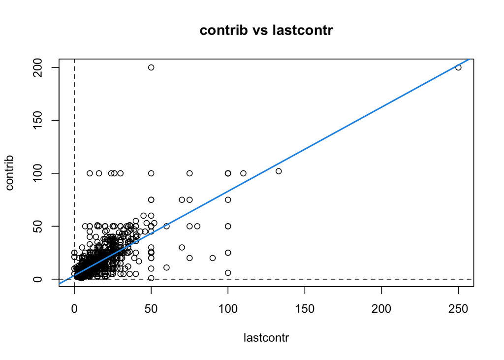

```r
plot(fundata[,c("lastcontr","contrib")],main = "contrib vs lastcontr")
abline(m,col=4,lwd=2)
abline(h=0,lty=2)
abline(v=0,lty=2)
```

4. Create diagnostic plots of the model and comment on any irregularities that they present. For instance, does the plot of residuals vs. fitted values suggest presence of non-linearity that remains unexplained by the model? Does scale-location plot suggest non-uniformity of variance along the range of fitted values? Are some standardized residuals far greater than theoretical quantiles? What about residuals vs. leverage plot and Cook’s distance contours therein? How does your conclusions compare to what’s shown in the plot of the predictor and outcome with regression line added to it – i.e. the plot that was generated above?

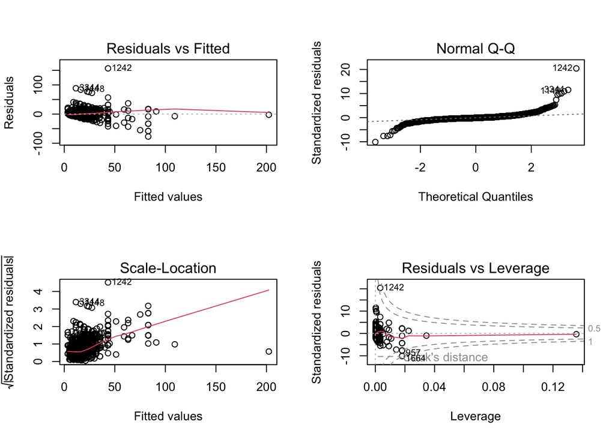

```r
par(mfrow=c(2,2))
plot(m)
```

**There is one fitted value that is much higher than the rest, resulting in all of the data being concentrated on the lefthand side of the plots. The residuals vs fitted plot shows funneling, indicating heteroscedasticity and some non-linearity. The normal Q-Q plot shows heavier tails. The scale-location plot shows a steep line, indicating non-uniformity of variance. The residuals vs leverage plot shows some influential data points very close to or above the 0.5 and 1 Cook’s distance lines and data points with high leverage and/or residuals. This suggests that outliers may be disproportionately influencing the fit of the model. The predictor and outcome plot corresponds with these diagnostic plots, as it shows many data points close to the low end of the regression line, which then spreads out very loosely around the line.**

5. Use function `confint` to obtain 95% confidence intervals on model parameters

```r
confint(m, level = 0.95)
```

```
##                 2.5 %    97.5 %
## (Intercept) 3.0898532 3.9561516
## lastcontr   0.7716243 0.8188294
```

6. Use this model and `predict` function to make predictions for the last contribution values of 10, 20 and 40. Remember that when you pass new data to `predict`, you have to make sure that the variable (column) names in those data match the predictor variable name(s) used in the model, otherwise `predict` will not know how to match the data to the model variables! Use `confidence` and `prediction` settings for parameter `interval` in the call to `predict` to obtain 90% confidence and prediction intervals on these model predictions (please double check what the default confidence level used by those functions is, and adjust if/as necessary).

```r
confpred = predict(m,newdata = data.frame(lastcontr = c(10, 20, 40)), interval="confidence", level = 0.9); confpred
```

```
##        fit      lwr      upr
## 1 11.47527 11.24031 11.71023
## 2 19.42754 19.18931 19.66577
## 3 35.33207 34.78873 35.87542
```

```r
predpred = predict(m,newdata = data.frame(lastcontr = c(10, 20, 40)), interval="prediction", level = 0.9); predpred
```

```
##        fit       lwr      upr
## 1 11.47527 -1.182759 24.13330
## 2 19.42754  6.769448 32.08563
## 3 35.33207 22.664568 47.99958
```

Explain the differences between interpretation of: - confidence intervals on model parameters and model predictions **Confidence intervals of model parameters are calculated based on the estimated standard error of the intercept and slope. The 90% confidence interval for the model parameters tells you that the slope and intercept will fall within the reported range, with 90% confidence. The 90% confidence intervals for the model predictions tells you that the true value will be within the lower and upper limit bounds 90% of the time.** - confidence and prediction intervals on model predictions **90% confidence intervals can be interpreted as the range an unknown parameter will fall within with 90% confidence. Prediction intervals can be interpreted as the range, with 90% confidence in this case, that future observations will fall within.** - comment on whether confidence or prediction intervals (on predictions) are wider and why **The prediction intervals are much wider than the confidence intervals, because the confidence interval accounts for the sampling uncertainty of many data points, wheras the prediction interval accounts for the sampling uncertainty and the uncertainty around a single value..**

# Problem 2: model using log-transformed attributes (20 points)

1. Use `lm()` to fit a regression model of *log-transformed* outcome (`contrib`) as a linear function of *log-transformed* last contribution and use `summary` to evaluate its results.

For the purposes of this exercise we can exclude small number of observations where `lastcontr==0`, otherwise log-transformation will result in negative infinity values for those and error from the call to `lm`. (And what does last contribution of zero represent in the first place, anyway?! Rounded values of contributions below 1? That’s a rhetorical question aimed at data producers, no need to answer it as part of this problem set.) When you exclude those observations with `lastcontr==0` please note in your solution how many exactly you have excluded.

```r
ex0 = subset(fundata, lastcontr!=0)
print("10 values of lastcontr == 0 are excluded.")
```

```
## [1] "10 values of lastcontr == 0 are excluded."
```

```r
logm = lm(log10(contrib) ~ log10(lastcontr), data = ex0)

logm.summary = summary(logm); logm.summary
```

```
##
## Call:
## lm(formula = log10(contrib) ~ log10(lastcontr), data = ex0)
##
## Residuals:
##      Min       1Q   Median       3Q      Max
## -1.59373 -0.07460  0.01121  0.09069  0.97954
##
## Coefficients:
##                  Estimate Std. Error t value Pr(>|t|)
## (Intercept)       0.20030    0.01293    15.5   <2e-16 ***
## log10(lastcontr)  0.82016    0.01149    71.4   <2e-16 ***
## ---
## Signif. codes:  0 '***' 0.001 '**' 0.01 '*' 0.05 '.' 0.1 ' ' 1
##
## Residual standard error: 0.1736 on 3458 degrees of freedom
## Multiple R-squared:  0.5958, Adjusted R-squared:  0.5957
## F-statistic:  5098 on 1 and 3458 DF,  p-value: < 2.2e-16
```

Now that we are done with that - can we compare the fits obtained using untransformed (above) and log-transformed attributes? Can we directly compare RSE from these two models? What about comparing $R^2$? What would we conclude from this? (Please consult ISLR Ch.3.1.3 if unsure) What would be the physical meaning of model coefficients this time? What does model intercept represent in this case, for example? How sensible is this and how does this compare to the meaning of the same parameter (intercept) obtained when fitting on untransformed data?

```r
paste('RSE (og/log10):',m.summary$sigma, logm.summary$sigma)
```

```
## [1] "RSE (og/log10): 7.69215442606569 0.173552337077219"
```

```r
paste('R2 (og/log10):',m.summary$r.squared, logm.summary$r.squared)
```

```
## [1] "R2 (og/log10): 0.557189123742337 0.595816463229322"
```

```r
m.summary$coefficients; logm.summary$coefficients
```

```
##              Estimate Std. Error  t value     Pr(>|t|)
## (Intercept) 3.5230024 0.22092142 15.94686 2.646504e-55
## lastcontr   0.7952268 0.01203814 66.05896 0.000000e+00
```

```
##                   Estimate Std. Error  t value     Pr(>|t|)
## (Intercept)      0.2003049 0.01292504 15.49743 2.011276e-52
## log10(lastcontr) 0.8201579 0.01148730 71.39691 0.000000e+00
```

**RSE is much smaller for the log-transformed model at 0.174, compared to 7.692 with the original model. This tells us that the lack of fit is greater for the original model, and the log-transformed model is a better fit. R-squared is slightly higher with the log-transformed model, at 0.596 compared to 0.557. This shows that the proportion of variability in contrib that can be explained by lastcontr is higher in the log-transformed model. The slope indicates that for every 1 increase in log10(lastcontr), log10(contrib) is expected to increase by 0.820. The intercept is lower at 0.200, compared to the untransformed 3.523; however, it corresponds to log10 values as opposed to the direct value of the intercept. Together, we can say that log10(contrib) = 0.820log10(lastcontr) + 0.2003.**

2. Create an XY-scatterplot of log-transformed predictor and response and add corresponding regression line to it. Compare it to the plot in untransformed coordinates obtained in Problem 1. What would you conclude from such comparison?

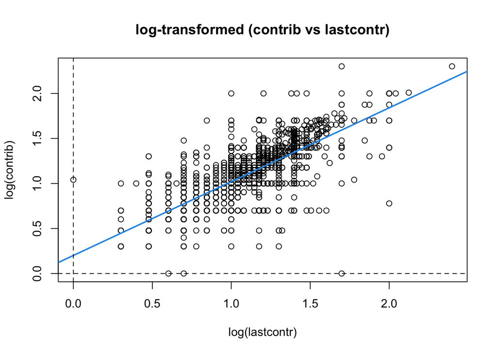

```r
plot(log10(ex0[,c("lastcontr","contrib")]),main = "log-transformed (contrib vs lastcontr)", ylab = 'log(contrib)', xlab = 'log(lastcontr)')
abline(logm,col=4,lwd=2)
abline(h=0,lty=2)
abline(v=0,lty=2)
```

**The log-transformed scatterplot shows a much better fit with the regression line. The data points are evenly dispersed along the line with similar variance throughout, as opposed to the untransformed plot which showed the data densely concentrated along the lower portion of the regression line with increased variance as the values increased.**

3. Make diagnostic plots for the model fit on log-transformed outcome and the last contribution. Compare them to the diagnostic plots generated in Problem 1 for the model fitted using original scale of measurements (untransformed). What can you conclude from this comparison about the relative quality of these two models?

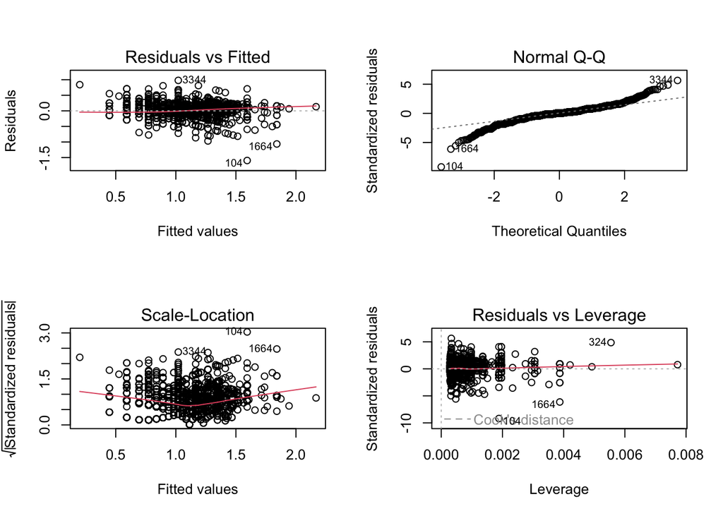

```r
par(mfrow=c(2,2))
plot(logm)
```

**The residuals vs fitted plot now shows more of a shapeless-cloud distribution with the line hovering around horizontal = 0. The scale-location plot shows a dip in the middle of the line; however, it is significantly more horizontal than the untransformed model. The residuals vs leverage plot no longer shows the 0.5 and 1 contours of Cook’s distance. Altogether, the diagnostic plots suggest a much better fit of the log-transformed model compared to the untransformed.**

# Problem 3: Adding second variable to the model (10 points)

To explore effects of adding another variable to the model, continue using log-transformed attributes and fit a model of log-transformed outcome (the same target campaign contribution, column `contrib` in `fund-raising.csv`) as a function of the last contribution and average contribution (both log-transformed). Just an additive model – no interaction term is necessary at this point. Please obtain and evaluate the summary of this model fit, confidence intervals on its parameters and its diagnostic plots. Where applicable, compare them to the model obtained above and reflect on pros and cons of including average contribution as another variable into the model. You may find the discussion of *variance inflation factor* (VIF) in ISLR Ch.3.3.3 (Section 6) and its implementation `vif` in `car` library particularly useful in this context.

```r
multlogm = lm(log10(contrib) ~ log10(lastcontr) + log10(avecontr), data = ex0)

multlogm.summary = summary(multlogm); multlogm.summary #summary
```

```
##
## Call:
## lm(formula = log10(contrib) ~ log10(lastcontr) + log10(avecontr),
##     data = ex0)
##
## Residuals:
##      Min       1Q   Median       3Q      Max
## -1.54620 -0.07094  0.00689  0.08570  0.99582
##
## Coefficients:
##                  Estimate Std. Error t value Pr(>|t|)
## (Intercept)       0.09595    0.01322   7.259  4.8e-13 ***
## log10(lastcontr)  0.49406    0.01922  25.701  < 2e-16 ***
## log10(avecontr)   0.46622    0.02269  20.547  < 2e-16 ***
## ---
## Signif. codes:  0 '***' 0.001 '**' 0.01 '*' 0.05 '.' 0.1 ' ' 1
##
## Residual standard error: 0.1639 on 3457 degrees of freedom
## Multiple R-squared:  0.6398, Adjusted R-squared:  0.6396
## F-statistic:  3070 on 2 and 3457 DF,  p-value: < 2.2e-16
```

```r
confint(multlogm) #confidence intervals
```

```
##                       2.5 %    97.5 %
## (Intercept)      0.07003149 0.1218633
## log10(lastcontr) 0.45636536 0.5317451
## log10(avecontr)  0.42173514 0.5107132
```

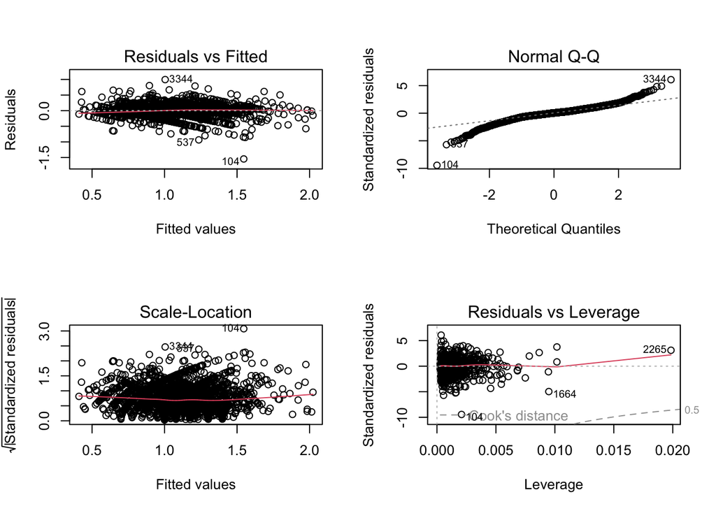

```r
par(mfrow = c(2,2))
plot(multlogm) #diagnostic plots
```

```r
library(car)
vif(multlogm) #VIF collinearity
```

```
## log10(lastcontr)  log10(avecontr)
##          3.14142          3.14142
```